# shap_theory

### 11. SHAP importance

- motivating case study
- game theoretic motivation
- translation to ML
- visualization

### Learning outcomes

1. Describe the theoretical foundation of post-hoc explanation methods like SHAP and linear probes values and apply them to realistic case studies with appropriate validation checks
2. Within a specific application context, evaluate the trade-offs associated with competing interpretable machine learning techniques.

### Motivating Case Study

Enhancers are stretches of the genome that coordinate the expression of many downstream genes.

- Their status is determined by combinations of binding transcription factors and chromatin marks

Understanding these interactions explains genotype $\to$ phenotype.

### Motivating Case Study

This can be studied using developing fruit flies.

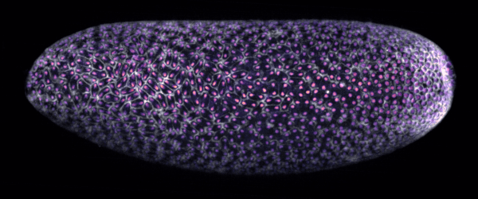

([source](https://www.thisiscolossal.com/2024/09/nikon-small-world-in-motion-2024/))

### Question

Which features drive enhancer activity in each sequence?

**Data**

Genome-wide measurements from blastoderm (stage 5) *Drosophila* embryos:

- DNA occupancy for 23 transcription factors
- Activity for 13 chromatin markers
- Binary labels indicating enhancer activity for genomic regions

Each observation: a genomic sequence with associated regulatory features.

### Statistical Formulation

**Enhancer status**: $y \in \{0,1\}$

**Predictors**: $x = (x_1, \ldots, x_D)$ (TF binding intensities, chromatin signals)

**Model**: $f(x_i) = \mathbb{P}(y_i = 1 \mid x_i)$

**Goal.** Quantify each feature’s contribution to $f(x_i)$.

## Game Theory

### Credit Assignment

How to distribute profit across employees $i$ in a company if any team $S$ has profit $v(S)$?

Game theoretic analogy.

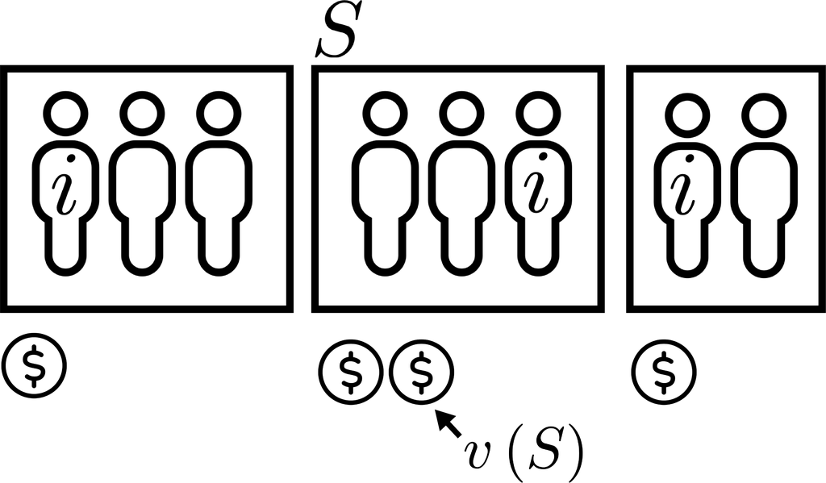

### Shapley Credit Assignment

Employee $i$’s credit: average marginal contribution $v(S) - v(S \setminus \{i\})$ over all teams $S \ni i$.

$$\begin{align}
\varphi(i) = \frac{1}{D} \sum_{d = 1}^{D} \frac{1}{\binom{D-1}{d-1}}\sum_{S \in S_{d}(i)} [v(S) - v(S \setminus \{i\})]
\end{align}$$

where $S_{d}(i)$ collects subsets of size $d$ containing $i$.

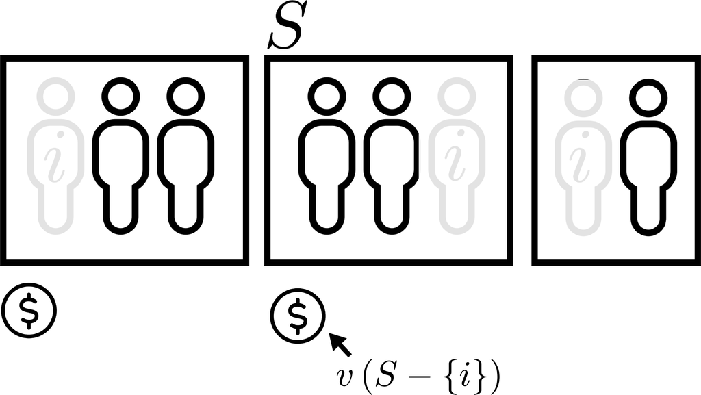

### Axioms

Shapley values are the unique credit assignment satisfying:

**Symmetry.** Equal marginal contributions $\to$ equal credit.
$$\begin{align*}
\varphi(i) = \varphi(j) \;\text{ if }\; v(S \cup \{i\}) - v(S) = v(S \cup \{j\}) - v(S) \;\; \forall S
\end{align*}$$

**Dummy.** Zero marginal contribution $\to$ zero credit.
$$\begin{align*}
\varphi(i) = 0 \;\text{ if }\; v(S \cup \{i\}) = v(S) \;\; \forall S
\end{align*}$$

**Additivity.** For two games $v_1, v_2$, attributions add.
$$\begin{align*}
\varphi_i(v_1 + v_2) = \varphi_i(v_1) + \varphi_i(v_2)
\end{align*}$$

### Efficiency

**Efficiency.** All credit is distributed, and no double counting.

$$\sum_{i=1}^D \varphi(i) = v(D) - v(\emptyset)$$

## Feature Attribution

### Game Theory $\to$ Machine Learning

For each prediction $f(x)$, define a game:

$$\begin{align}
v_{x}(S) = \mathbb{E}_{p(x'_{S^C} \mid x_{S})}[f(x_{S}, x'_{S^C})]
\end{align}$$

where $x_S$ denotes coordinates in $S$ fixed at their observed values, and $x'_{S^C}$ are the remaining coordinates drawn from their conditional distribution.

How to define $v(S)$? This determines what “importance” means.

### Shapley Feature Attribution

Feature $i$’s contribution to $f(x)$:

$$\begin{align}
\varphi_{x}(f, i) = \frac{1}{D} \sum_{d = 1}^{D} \frac{1}{\binom{D-1}{d-1}}\sum_{S \in S_{d}(i)}[v_{x}(S) - v_{x}(S \setminus \{i\})]
\end{align}$$

These satisfy:
$$\sum_{i=1}^D \varphi_{x}(f, i) = f(x) - \mathbb{E}[f(X)]$$

Each $\varphi_x(f,i)$ explains deviation from baseline prediction.

### Geometric Interpretation

$$\begin{align}
v_{x}(S) = \mathbb{E}_{p(x'_{S^C} \mid x_{S})}[f(x_{S}, x'_{S^C})]
\end{align}$$

[figure not shown]

Conditional expectation when features $S$ are fixed at $x_S$.

### Exercise: SHAP Visual Explanation

Respond to [SHAP Visual Explanation] in the exercise sheet.

### Main Difficulty

The conditional expectation $\mathbb{E}[f(x_S, X_{S^C}) \mid x_S]$ is generally **not computable**.

This forces a choice:

1. **Marginal Shapley.** Replace with $\mathbb{E}[f(x_S, X_{S^C})]$
   - Ignores feature correlations
   - Reveals model’s functional form
2. **Conditional Shapley.** Model $p(x_{S^C} \mid x_S)$
   - Respects correlations
   - Hard to estimate, often biased

We discuss this further next week.

### Visualization - One Sample

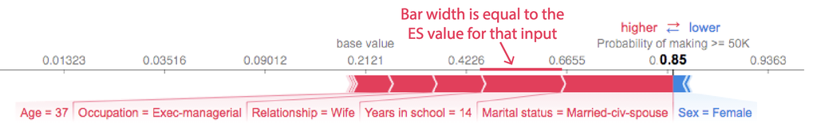

### Visualization - Many Samples

Compact visualization identifies samples with similar explanations.

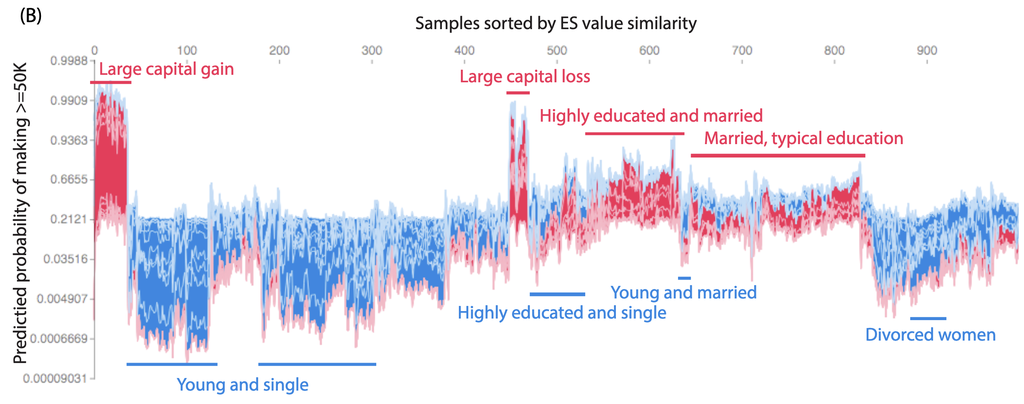